# wrangle_act

## Gathering Data

I imported and aliased the necessary packages.

```python
import pandas as pd
import numpy as np
import requests as req
import tweepy
import json
import matplotlib
```

### I. df_enhanced dataset

```python
df_enhanced = pd.read_csv('twitter-archive-enhanced.csv')
```

```python
df_enhanced.head()
```

|  | tweet_id | in_reply_to_status_id | in_reply_to_user_id | timestamp | source | text | retweeted_status_id | retweeted_status_user_id | retweeted_status_timestamp | expanded_urls | rating_numerator | rating_denominator | name | doggo | floofer | pupper | puppo |
| --- | --- | --- | --- | --- | --- | --- | --- | --- | --- | --- | --- | --- | --- | --- | --- | --- | --- |
| 0 | 892420643555336193 | NaN | NaN | 2017-08-01 16:23:56 +0000 | <a href="http://twitter.com/download/iphone" r... | This is Phineas. He's a mystical boy. Only eve... | NaN | NaN | NaN | https://twitter.com/dog_rates/status/892420643... | 13 | 10 | Phineas | None | None | None | None |
| 1 | 892177421306343426 | NaN | NaN | 2017-08-01 00:17:27 +0000 | <a href="http://twitter.com/download/iphone" r... | This is Tilly. She's just checking pup on you.... | NaN | NaN | NaN | https://twitter.com/dog_rates/status/892177421... | 13 | 10 | Tilly | None | None | None | None |
| 2 | 891815181378084864 | NaN | NaN | 2017-07-31 00:18:03 +0000 | <a href="http://twitter.com/download/iphone" r... | This is Archie. He is a rare Norwegian Pouncin... | NaN | NaN | NaN | https://twitter.com/dog_rates/status/891815181... | 12 | 10 | Archie | None | None | None | None |
| 3 | 891689557279858688 | NaN | NaN | 2017-07-30 15:58:51 +0000 | <a href="http://twitter.com/download/iphone" r... | This is Darla. She commenced a snooze mid meal... | NaN | NaN | NaN | https://twitter.com/dog_rates/status/891689557... | 13 | 10 | Darla | None | None | None | None |
| 4 | 891327558926688256 | NaN | NaN | 2017-07-29 16:00:24 +0000 | <a href="http://twitter.com/download/iphone" r... | This is Franklin. He would like you to stop ca... | NaN | NaN | NaN | https://twitter.com/dog_rates/status/891327558... | 12 | 10 | Franklin | None | None | None | None |

```python
df_enhanced.tail()
```

|  | tweet_id | in_reply_to_status_id | in_reply_to_user_id | timestamp | source | text | retweeted_status_id | retweeted_status_user_id | retweeted_status_timestamp | expanded_urls | rating_numerator | rating_denominator | name | doggo | floofer | pupper | puppo |
| --- | --- | --- | --- | --- | --- | --- | --- | --- | --- | --- | --- | --- | --- | --- | --- | --- | --- |
| 2351 | 666049248165822465 | NaN | NaN | 2015-11-16 00:24:50 +0000 | <a href="http://twitter.com/download/iphone" r... | Here we have a 1949 1st generation vulpix. Enj... | NaN | NaN | NaN | https://twitter.com/dog_rates/status/666049248... | 5 | 10 | None | None | None | None | None |
| 2352 | 666044226329800704 | NaN | NaN | 2015-11-16 00:04:52 +0000 | <a href="http://twitter.com/download/iphone" r... | This is a purebred Piers Morgan. Loves to Netf... | NaN | NaN | NaN | https://twitter.com/dog_rates/status/666044226... | 6 | 10 | a | None | None | None | None |
| 2353 | 666033412701032449 | NaN | NaN | 2015-11-15 23:21:54 +0000 | <a href="http://twitter.com/download/iphone" r... | Here is a very happy pup. Big fan of well-main... | NaN | NaN | NaN | https://twitter.com/dog_rates/status/666033412... | 9 | 10 | a | None | None | None | None |
| 2354 | 666029285002620928 | NaN | NaN | 2015-11-15 23:05:30 +0000 | <a href="http://twitter.com/download/iphone" r... | This is a western brown Mitsubishi terrier. Up... | NaN | NaN | NaN | https://twitter.com/dog_rates/status/666029285... | 7 | 10 | a | None | None | None | None |
| 2355 | 666020888022790149 | NaN | NaN | 2015-11-15 22:32:08 +0000 | <a href="http://twitter.com/download/iphone" r... | Here we have a Japanese Irish Setter. Lost eye... | NaN | NaN | NaN | https://twitter.com/dog_rates/status/666020888... | 8 | 10 | None | None | None | None | None |

### II. df_breed Dataset

```python
r = req.get('https://d17h27t6h515a5.cloudfront.net/topher/2017/August/599fd2ad_image-predictions/image-predictions.tsv')
```

I checked the content type and separator.

```python
r.headers['content-type']
```

```
'text/tab-separated-values; charset=utf-8'
```

I saved a path into a variable and read in the file.

```python
path = 'https://d17h27t6h515a5.cloudfront.net/topher/2017/August/599fd2ad_image-predictions/image-predictions.tsv'
```

```python
df_breed = pd.read_csv(path, sep = '\t')
```

```python
df_breed.head()
```

|  | tweet_id | jpg_url | img_num | p1 | p1_conf | p1_dog | p2 | p2_conf | p2_dog | p3 | p3_conf | p3_dog |
| --- | --- | --- | --- | --- | --- | --- | --- | --- | --- | --- | --- | --- |
| 0 | 666020888022790149 | https://pbs.twimg.com/media/CT4udn0WwAA0aMy.jpg | 1 | Welsh_springer_spaniel | 0.465074 | True | collie | 0.156665 | True | Shetland_sheepdog | 0.061428 | True |
| 1 | 666029285002620928 | https://pbs.twimg.com/media/CT42GRgUYAA5iDo.jpg | 1 | redbone | 0.506826 | True | miniature_pinscher | 0.074192 | True | Rhodesian_ridgeback | 0.072010 | True |
| 2 | 666033412701032449 | https://pbs.twimg.com/media/CT4521TWwAEvMyu.jpg | 1 | German_shepherd | 0.596461 | True | malinois | 0.138584 | True | bloodhound | 0.116197 | True |
| 3 | 666044226329800704 | https://pbs.twimg.com/media/CT5Dr8HUEAA-lEu.jpg | 1 | Rhodesian_ridgeback | 0.408143 | True | redbone | 0.360687 | True | miniature_pinscher | 0.222752 | True |
| 4 | 666049248165822465 | https://pbs.twimg.com/media/CT5IQmsXIAAKY4A.jpg | 1 | miniature_pinscher | 0.560311 | True | Rottweiler | 0.243682 | True | Doberman | 0.154629 | True |

### III. df_tweets Dataset

```python
consumer_key = "6VDcGBjSWqKEqDc3KLRxxxxxx"
consumer_secret = "dIqS612VGEQ76knOcDAkNQKtlakhSInYop7Y2FC9q9Clxxxxxx"
access_token = '966777955253854208-7myYzBBBExONErFUbbaSnZLFExxxxxx'
access_secret = 'dyApREzYyE7X9xZbItW9HohQE4E8kXucK6weVkGxxxxxx'

auth = tweepy.OAuthHandler(consumer_key, consumer_secret)
auth.set_access_token(access_token, access_secret)

api = tweepy.API(auth, wait_on_rate_limit=True)
```

Create a list of tweet ids to iterate through it.

```python
id_list = df_enhanced['tweet_id']
```

```python
id_list
```

```
0       892420643555336193
1       892177421306343426
2       891815181378084864
3       891689557279858688
4       891327558926688256
5       891087950875897856
6       890971913173991426
7       890729181411237888
8       890609185150312448
9       890240255349198849
10      890006608113172480
11      889880896479866881
12      889665388333682689
13      889638837579907072
14      889531135344209921
```

[output cut: 47 more lines]

Source: https://stackoverflow.com/questions/34379168/how-to-save-the-tweets-in-json-to-txt-file-in-python-3-4

```python
# creating a list for the exceptions
exceptions_list = []

# opening the file to write
with open('tweet_json.txt', 'w', encoding = 'utf-8') as f:
    for id_tweet in id_list:
        try:
            tweet = api.get_status(id_tweet, tweet_mode= 'extended')
            json.dump(tweet._json, f)
# writing the content witt new paragraphs
            f.write("\n")
        except Exception as e:
            exceptions_list.append(id_tweet)
# printing out the exception messages
            print(str(e))
```

[output not shown]

[output cut: 2178 more lines]

[output not shown]

[output not shown]

[output cut: 80 more lines]

[output not shown]

```python
# Reading the json file

df_full_json = pd.read_json('tweet_json.txt', orient='records', lines = True)
```

```python
# Checking the columns to find out which values we would like to extract.

df_full_json.columns
```

```python
# As I should exclude retweets, I also want to know a tweet's retweet status.

df_tweets = df_full_json[['id','favorite_count', 'retweet_count', 'retweeted']]
```

```python
df_tweets.head()
```

```python
df_tweets.tail()
```

## Assesing Data

### I. df_tweets dataset

Print out the df_tweets dataset.

```python
df_tweets
```

```python
len(df_tweets.query('retweeted == True'))
```

I checked if there ary any duplicated value by id.

```python
df_tweets[df_tweets['id'].duplicated(keep=False)]
```

```python
df_tweets.info()
```

After asessing, I can assume, that there are not any particular problem with this dataframe.

### II. df_enhanced dataset

I printed out the archive dataset.

```python
df_enhanced
```

I counted and grouped the dognames to discover the invalid dog names in the dataset. According to my observations, all the incorrect dog names start with a lower case letter and are detected as name based on the text column.

```python
df_enhanced[['name']].groupby(['name'])['name'].size()
```

Cheking the null values and datatypes.

```python
df_enhanced.info()
```

I ckecked if there are any values duplicated by their id.

```python
df_enhanced[df_enhanced['tweet_id'].duplicated(keep=False)]
```

### III. df_breed

```python
df_breed.head()
```

I checked the datatypes.

```python
df_breed.info()
```

Listing the null values (if there are any).

```python
nulls = df_breed.columns[df_breed.isnull().any()]
df_breed[nulls].isnull().sum()
```

## Summary

#### Tidiness:

- there are 3 dataset instead of 1 master dataset

df_enhanced dataset:

- unecessary source column with hardly readable information
- unecessary category columns: doggo, floofer, pupper, puppo

df_breed dataset:

- no need of infos of some columns:
- too many stages column instead of one
- stages column could be categorical datatype

#### Quality:

df_enhanced dataset:

- the dog_stage is string datatype
- unecessary rating denominator column, rating numerator column header without scale
- incorrect names, missing names in name column: such?, quite, a, an, the... - all are written with lower case letters
- retweeted records: retweeted_status_id, retweeted_status_user_id, retweeted_status_timestamp
- missing data in name and stages columns showing as 'None'
- incorrect datatypes: timestamp is string
- in_reply_to_status_id, in_reply_to_user_id should be changed from sciantific float to string

df_breed dataset:

- dog breeds start with lower case letters
- non-dog records in the dataset (eg.: shopping cart, box turtle...)
- the p1, p2, p2 columns shoulf be categorical datatypes

## Cleaning Process

### I. df_enhanced Data

Count the number of retweeted tweets from df_enhanced dataframe.

```python
len(df_enhanced.query('retweeted_status_id != "NaN"'))
```

Creaing a new dataframe without the retweeted tweets.

```python
df_enhanced = df_enhanced.query('retweeted_status_id == "NaN"')
```

Doublechecking the results.

```python
len(df_enhanced.query('retweeted_status_id != "NaN"'))
```

I dropped the unecessary empty columns.

```python
df_enhanced = df_enhanced.drop(['retweeted_status_id', 'retweeted_status_user_id', 'retweeted_status_timestamp'], axis=1)
```

I deleted the unecessary rating denominator column and rename the rating numerator include and mark the rating denominator as well.

```python
df_enhanced = df_enhanced.drop('rating_denominator', axis=1)
```

```python
df_enhanced = df_enhanced.rename(index=str, columns={"rating_numerator": "rating_10_scale"})
```

```python
df_enhanced.head(3)
```

I decided to extract the dog names from the text columns to replace the missing values and correct the incorrect dog names. The valied dog names start with upper-case letters.

I collect some of the cases and expressions when the dog names occur in the text column in the following context:

```
- ... named [Dog Name]
- meet [Dog Name]
- .. name is [Dog Name]
- This is [Dog Name]
- Say hello to [Dog Name]
- Meet [Dog Name]
- Here we have [Dog Name]
- Here is [Dog Name]
```

Then I will iterate through the text column and change the value in the name column based on the text column.

```python
import re

# Creating two lists: one for the names we can' extract and one for the new names
names_clean = []
missing_names = []

# Creating a lit of the texts
text_list = df_enhanced['text'].values.tolist()

# Creating a regex pattern
pattern = re.compile('([A-Z].*)')

# Iterating thourgh the text list and check if the content and pattern correspond to some of the extressions
for text in df_enhanced['text']:

    if text.__contains__('This is') and pattern.fullmatch(text.split()[text.split().index("is")+1]):
        names_clean.append(text.split(" ")[2].strip('.').strip(','))
        print("this_is__", text.split(" ")[2].strip('.').strip(','))
    elif text.startswith("Meet") and pattern.fullmatch(text.split(" ")[1]):
        names_clean.append(text.split(" ")[1].strip('.').strip(','))
        print("meet__", text.split(" ")[1].strip('.').strip(','))
    elif text.startswith("Here we have") and pattern.fullmatch(text.split(" ", 3)[3]):
        names_clean.append(text.split(" ")[3].strip('.').strip(','))
        print("here_we_have__", text.split(" ")[3].strip('.').strip(','))
    elif text.split(" ").__contains__("named") and pattern.fullmatch(text.split()[text.split().index("named")+1]):
        names_clean.append(text.split()[text.split().index("named")+1].strip('.').strip(','))
        print("__named__", text.split()[text.split().index("named")+1].strip('.').strip(','))
    elif text.__contains__("name is") and pattern.fullmatch(text.split()[text.split().index("is")+1]):
        names_clean.append(text.split()[text.split().index("is")+1].strip('.').strip(','))
        print("__name__is__", text.split()[text.split().index("is")+1].strip('.').strip(','))
    elif text.__contains__("Say hello to") and pattern.fullmatch(text.split()[text.split().index("to")+1]):
        names_clean.append(text.split(" ")[3].strip('.').strip(','))
        print("say_hello_to__", text.split(" ")[3])
    else:
        names_clean.append("NaN")
        missing_names.append(text)
```

```python
len(names_clean)
```

Checking the number of the missing names.

```python
len(missing_names)
```

I looked at the content to see if there are any dog names to extract.

```python
missing_names
```

Save the new names into the dataframe

```python
df_enhanced['dog_name'] = names_clean
```

```python
len(df_enhanced['dog_name'])
```

Compare the original names column with the new, cleaned one.

```python
df_enhanced[['name']].groupby(['name'])['name'].size()
```

Looking at the new names.

```python
df_enhanced[['dog_name']].groupby(['dog_name'])['dog_name'].size()
```

```python
df_enhanced['dog_name'] = df_enhanced['dog_name'].replace(to_replace = r'^([a-z])', value = np.nan, regex = True)
```

Final result.

```python
df_enhanced[['dog_name']].groupby(['dog_name'])['dog_name'].size()
```

Looking at the missing values.

```python
df_enhanced[df_enhanced['dog_name'] == "NaN"]
```

I dropped the name column.

```python
df_enhanced = df_enhanced.drop('name', axis = 1)
```

Changing the incorrect data types:

- timestamp
- retweeted_status_id
- retweeted_status_user_id
- retweeted_status_timestamp

```python
df_enhanced.info()
```

```python
df_enhanced.timestamp = pd.to_datetime(df_enhanced.timestamp)
```

```python
df_enhanced.info()
```

```python
df_enhanced.head(3)
```

According to the following post values with float datatype can not be converted to integer if there are any missing values and NaN data. I did not want to replace the missing values with 0 by using the fillna() function. So, I decided to convert the ids to object and scientific format to simple format. There is not any problem with that as we treat these id values as strings and do not expect to do any numerical operations with them anyway.

https://stackoverflow.com/questions/41550746/error-using-astype-when-nan-exists-in-a-dataframe

I used lambda and map function to convert floats in scientific format to simple string format in case of in_reply_to_status_id and in_reply_to_user_id.

https://stackoverflow.com/questions/41157981/pandas-convert-float-in-scientific-notation-to-string/41158287

```python
df_enhanced['in_reply_to_status_id'] = df_enhanced.in_reply_to_status_id.map(lambda x: '{:.0f}'.format(x))
df_enhanced['in_reply_to_user_id'] = df_enhanced.in_reply_to_user_id.map(lambda x: '{:.0f}'.format(x))
```

Double cheking the results.

```python
df_enhanced[df_enhanced['in_reply_to_status_id'] != 'nan']
```

```python
df_enhanced.columns
```

```python
df_enhanced.info()
```

I merged the dog stage columns into one column.

```python
columns_melt = ['doggo', 'floofer', 'pupper', 'puppo']
columns_remain = [item for item in df_enhanced.columns.tolist() if item not in columns_melt]


df_enhanced = pd.melt(df_enhanced, id_vars = columns_remain, value_vars = columns_melt,
                         var_name = 'stages', value_name = 'dog_stage')
```

```python
df_enhanced = df_enhanced.drop('stages', axis = 1)
```

```python
df_enhanced.duplicated(subset = "tweet_id").sum()
```

I sorted and deleted the duplicate data. I had to keep the last records because the first had None values.

```python
df_enhanced = df_enhanced.sort_values('dog_stage').drop_duplicates('tweet_id', keep = 'last')
```

```python
df_enhanced.dog_stage.value_counts()
```

Double check the results: print out the lenght and count the duplicate data by id.

```python
len(df_enhanced)
```

```python
df_enhanced.duplicated(subset = "tweet_id").sum()
```

I dropped the unecessary long source column a create a new column based on the source values.

```python
print(df_enhanced['source'])
```

I extracted the source of the source column.

```python
source = df_enhanced['source']

user_source = []

for item in df_enhanced['source']:
    if item.__contains__("Twitter for iPhone"):
        user_source.append("Twitter for iPhone")
    elif item.__contains__("Twitter Web Client"):
        user_source.append("Twitter Web Client")
    elif item.__contains__('Vine - Make a Scene'):
        user_source.append("Vine")
    elif item.__contains__('TweetDeck'):
        user_source.append("TweetDeck")
```

Doublecheck if we could capture all the values. The output should be True.

```python
len(user_source) == len(df_enhanced['source'])
```

Append the list to the df_enhanced dataset.

```python
df_enhanced['user_source'] = user_source
```

```python
df_enhanced['user_source'].head(15)
```

Drop the unecessary source column.

```python
df_enhanced = df_enhanced.drop(['source'], axis = 1)
```

Change the datatype from string to categorical - user_source column.

```python
df_enhanced['user_source'] = df_enhanced.user_source.astype('category')
```

```python
df_enhanced.info()
```

```python
df_enhanced.head(3)
```

I merged the df_enhanced and df_tweets dataframe together by id values, using left join.

```python
df_clean = pd.merge(left=df_enhanced,right=df_tweets, left_on='tweet_id', right_on='id', how = 'left')
```

Drop the unecessary id and retweeted columns.

```python
df_clean = df_clean.drop(['id', 'retweeted'], axis = 1)
```

### Cleaning II: df_breed dataset

I queried records where p1_dog, p2_dog, p3_dog are false, indicating that not dog is shown in the pictures. I manual checked some of the pictures, and there are still pictures of dogs, but queried result mostly contains pictures not showing dogs.

```python
df_breed.query('p1_dog == False and p2_dog == False and p3_dog == False')
```

Based on my observations, I decided keep as many data as possible, so I created a new dataframe with the values where any of the boolean columns is true.

```python
df_breed = df_breed.query('p1_dog == True or p2_dog == True or p3_dog == True')
```

Doublecheck the process.

```python
df_breed.query('p1_dog == False and p2_dog == False and p3_dog == False')
```

```python
df_breed.columns
```

```python
df_breed.head()
```

Changing the dog breeds from lower case letters to upper case letters and remove the _ characters to make the form alike.

```python
df_breed['p1'] = df_breed.p1.str.capitalize()
df_breed['p2'] = df_breed.p1.str.capitalize()
df_breed['p3'] = df_breed.p1.str.capitalize()
```

```python
df_breed['p1'].replace(regex=True,inplace=True,to_replace="_",value=r' ')
df_breed['p2'].replace(regex=True,inplace=True,to_replace="_",value=r' ')
df_breed['p3'].replace(regex=True,inplace=True,to_replace="_",value=r' ')
```

```python
df_breed.head()
```

Merging df_breed dataset with the df_clean dataset using left join to create one final dataset.

```python
df_master = pd.merge(left=df_clean,right=df_breed, left_on='tweet_id', right_on='tweet_id', how = 'left')
```

Doublechecking the results.

```python
df_master.head()
```

To make better analyzis, I decided to changing some datatypes to categorical in the master dataset.

```python
df_master.dog_name = df_master.dog_name.astype('category');
df_master.dog_stage = df_master.dog_stage.astype('category');
df_master ['p1'] = df_master.p1.astype('category');
df_master ['p2'] = df_master.p1.astype('category');
df_master ['p3'] = df_master.p1.astype('category');
```

```python
df_master.info()
```

I saved the dataset as a csv file.

```python
df_master.to_csv('twitter_archive_master.csv')
```

## Analyzing and Visualizing Data

```python
import matplotlib.pyplot as plt
import seaborn as sns

%matplotlib inline
```

```python
df_master = pd.read_csv('twitter_archive_master.csv')
```

```python
df_master.head()
```

#### I. Possible Correlations

```python
# Creating a smaller df with the numerical values to make a hetmap matrix of the correlations
df_corr_values = df_master[['rating_10_scale', 'favorite_count',
                               'retweet_count']].copy()

fig, ax = plt.subplots(figsize=(9,8))

corr = df_corr_values.corr()
sns.heatmap(corr,
            xticklabels=corr.columns.values,
            yticklabels=corr.columns.values,
            ax=ax,
            linewidth= 0.5)
```

[output not shown]

#### II. Most Popular Dog Names on the Account

I would like to find the most popular dog names. As rating has not anything to do with popularity, in this case, I will rate popularity by the number of tweets, assuming that the most popular dog names occur more times on the site.

```python
df_name = df_master.groupby('dog_name').filter(lambda x: len(x) >= 6)
fig, ax = plt.subplots(figsize=(8,6))
df_name['dog_name'].value_counts().plot(kind = 'bar', color = "#348A94", ax = ax, edgecolor = ['Black']*len(df_name))
ax.set_facecolor('#D3D3D3')
plt.show();
```

[output not shown]

#### II. Most Beloved Breeds

After that, I analyzed the relationship between the numbers of favorite and dog breeds to find out which dog breeds are the most beloved by the users. I used the most relevant results of the machine learning values, categorized the dog breeds based on pictures. According to my results, golden retrivers are the all time favorites among the users with more than 1600000 favorites, the second and third breeds are labrador retrievers (about 1100000 favorites) and pembrokes (about 1000000 favorites).

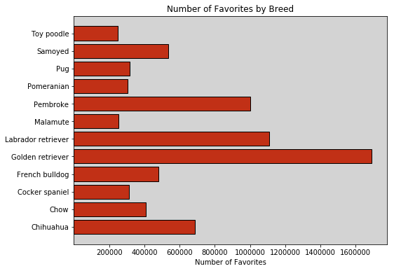

```python
# Creating a favorite dataframe by the gropped breeds, counted the favorites.
df_favorite = df_breed.groupby('p1')['favorite_count'].sum().reset_index()
ser_fav = df_favorite['favorite_count']
ser_breed = df_favorite['p1']

fig, ax = plt.subplots(figsize=(8,6))
fav = plt.barh(ser_breed, ser_fav, color = "#C13016", edgecolor = ['Black']*len(ser_breed))
ax.set_facecolor('#D3D3D3')
plt.xlabel('Number of Favorites')
plt.title('Number of Favorites by Breed')
plt.xticks(np.arange(200000, 1800000, 200000))
plt.show()
```

#### III. Dog Stages

I analyzed the specific "dog stages", excluding the missing values to make a pie chart about the proportions of the categories. The most often used stage is "pupper" with more than 65%, the second one is "doggo" (about 22%). The account owners use the words puppo and floofer in 10% of the cases alltogether.

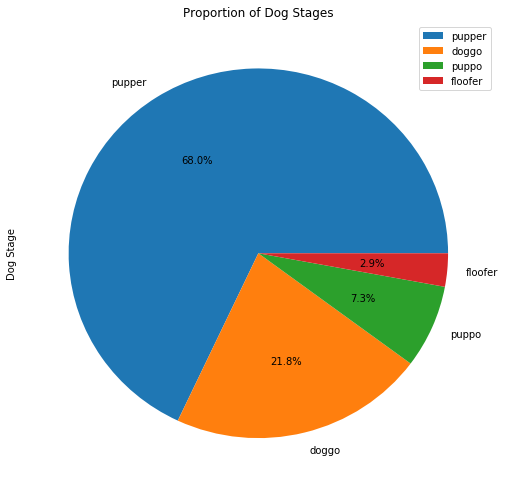

```python
# Exclude the cases where the dog stage is missing.
df_stage = df_master[df_master['dog_stage'] != "None"]
fig, ax = plt.subplots(figsize=(8.5,8.5))

df_stage['dog_stage'].value_counts().plot(kind = 'pie', ax = ax, label = 'Dog Stage', autopct='%1.1f%%')
plt.title('Proportion of Dog Stages')
plt.legend()
```

#### IV. Ratings

```python
# Exclude the negative or null values from the dataframe
df_cuteness = df_master[df_master['rating_10_scale'] > 0]
```

```python
cute_label = ['Good Dog (0.999, 9.0]', 'Adorable (9.0, 10.0]', 'Supertcute (10.0, 11.0]', 'Unbelieveable (11.0, 12.0]', 'Can I pet her pleeeeease?  (12.0, 13.0]', 'Who is the good boy? (13.0, 1776.0]']

cute_bins = pd.qcut(df_cuteness['rating_10_scale'], 6, labels = cute_label)
```

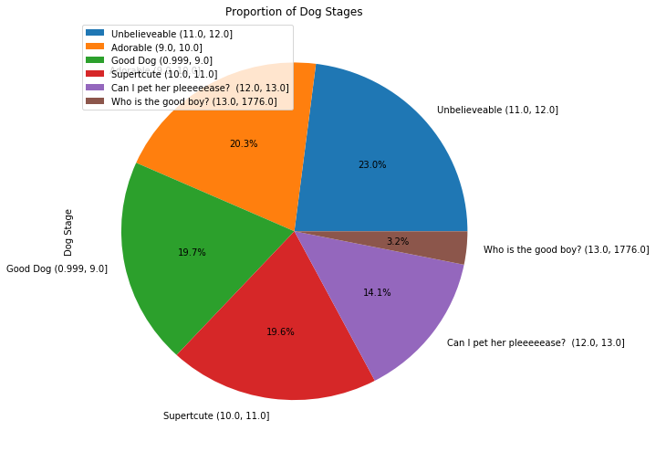

```python
fig, ax = plt.subplots(figsize=(8.5,8.5))
cute_bins.value_counts().plot(kind = 'pie', ax = ax, label = 'Dog Stage', autopct='%1.1f%%')
plt.title('Proportion of Dog Stages')
plt.legend()
```